# ms4.Rmd

Scott

3/6/2020

So far, I have loaded in 3 different data sets. Hopefully, Alyssa and I can find a way to loop through other websites to find an easier way to get data from different htmls rather thasn having to copy and paste it into an excel or having to load in each and every webpage. With the data right now, I spent a good amount of time tyding it so that it is easier to manipulate. Now, it is visually easier to understand and easier to use. I have begun to graph different variables but am still playing around with better ways to visually highlight things. As of right now. The graphs are contained solely to 2019, but I want to begin to expand to other years and add new variables once I get new data sets. Also, I want to be able to separate stats by teams throughout time, but now that I figure out how to best use my data and organize it, things seem to be getting easier to visualize. We can already see trends on the two graphs I have made. I found this data on MLB websites and am continuing to look for more.

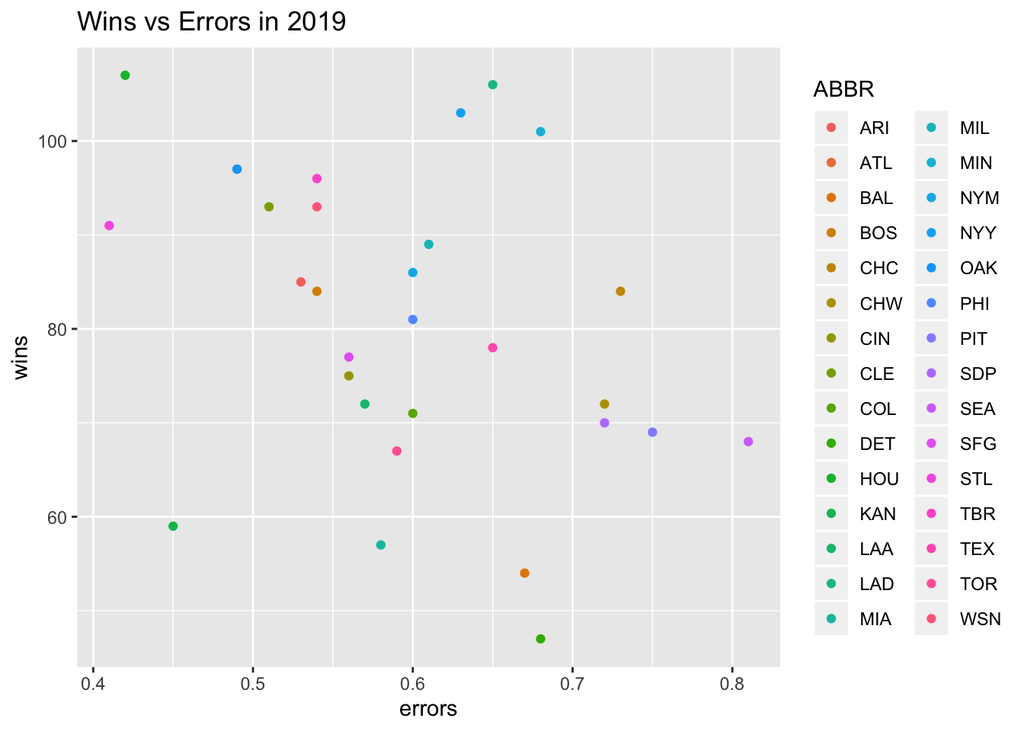

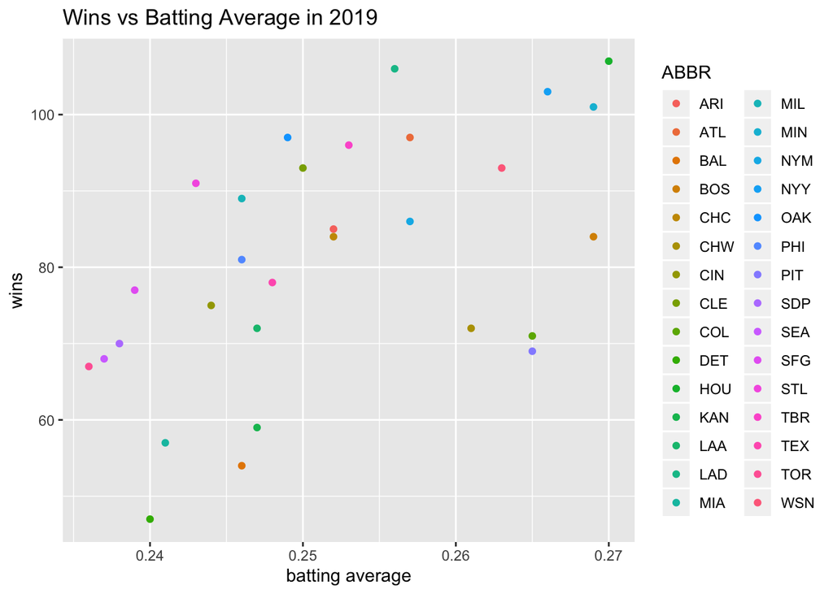